# lab4

## 4. Feature engineering (Challenging)

rubric={reasoning}

**Your tasks:**

1. Carry out feature engineering. In other words, extract new features relevant for the problem and work with your new feature set in the following exercises. You may have to go back and forth between feature engineering and preprocessing.

*Points:* 0.5

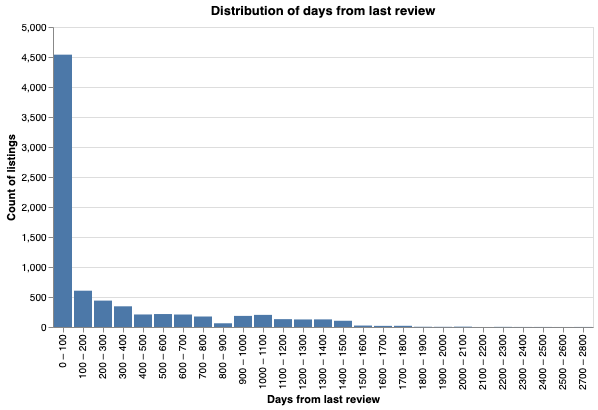

```python
from sklearn.preprocessing import KBinsDiscretizer

discretization_feats = ["latitude", "longitude"]

# We will add this code in the preprocessor section below.
# KBinsDiscretizer(n_bins=20, encode="onehot"), discretization_feats

# We will also add a new column called 'days_from_last_review'
# this feature calculates the timespan from the last review
# may be potentially helpful when predictive the review rate

# latest_day = max(pd.to_datetime(train_df["last_review"]))
# train_df["days_from_last_review"] = (
#      latest_day - (pd.to_datetime(train_df["last_review"]))
# ).dt.days

test_df["days_from_last_review"] = (
   latest_day - (pd.to_datetime(test_df["last_review"]))
).dt.days

alt.Chart(train_df, title="Distribution of days from last review").mark_bar().encode(
    x=alt.X("days_from_last_review:N", title="Days from last review", bin=alt.Bin(maxbins=30)),
    y=alt.Y("count()", title="Count of listings")
)
```

```python
train_df.head()
```

|  | id | name | host_id | host_name | neighbourhood_group | neighbourhood | latitude | longitude | room_type | price | minimum_nights | number_of_reviews | last_review | reviews_per_month | calculated_host_listings_count | availability_365 | days_from_last_review |
| --- | --- | --- | --- | --- | --- | --- | --- | --- | --- | --- | --- | --- | --- | --- | --- | --- | --- |
| 27438 | 21630372 | Beautiful and confortable room | 109146538 | Marisol | Queens | Jackson Heights | 40.75184 | -73.88722 | Private room | 60 | 1 | 46 | 2019-07-01 | 2.29 | 1 | 30 | 7 |
| 13825 | 10435733 | Cute Spacious Williamsburg Apt | 5927655 | Ann | Brooklyn | Williamsburg | 40.71892 | -73.95616 | Private room | 115 | 3 | 27 | 2018-10-29 | 0.69 | 1 | 56 | 252 |
| 473 | 166983 | 3 BR, Beautiful Brooklyn Duplex | 795640 | Jilly | Brooklyn | Carroll Gardens | 40.68252 | -73.99619 | Entire home/apt | 350 | 5 | 6 | 2015-08-08 | 0.06 | 1 | 0 | 1430 |
| 46103 | 35081477 | West Village Gem! Like Paris | 196890 | Siobhan | Manhattan | West Village | 40.72905 | -74.00294 | Entire home/apt | 165 | 2 | 2 | 2019-06-23 | 1.62 | 1 | 21 | 15 |
| 33450 | 26443376 | Big 1BR in PRIME Bushwick! 2 blocks to L Train! | 6293227 | Nish | Brooklyn | Bushwick | 40.70148 | -73.91834 | Entire home/apt | 90 | 3 | 9 | 2019-06-01 | 0.74 | 1 | 0 | 37 |

## 5. Preprocessing and transformations

rubric={accuracy,reasoning}

**Your tasks:**

1. Identify different feature types and the transformations you would apply on each feature type.
2. Define a column transformer, if necessary.

*Points:* 4

```python
X_train, y_train = (
    train_df.drop(columns=["reviews_per_month"]),
    train_df["reviews_per_month"],
)
X_test, y_test = (
    test_df.drop(columns=["reviews_per_month"]),
    test_df["reviews_per_month"],
)
```

```python
train_df.columns.to_list()
```

```
['id',
 'name',
 'host_id',
 'host_name',
 'neighbourhood_group',
 'neighbourhood',
 'latitude',
 'longitude',
 'room_type',
 'price',
 'minimum_nights',
 'number_of_reviews',
 'last_review',
 'reviews_per_month',
 'calculated_host_listings_count',
 'availability_365',
 'days_from_last_review']
```

```python
from sklearn.compose import ColumnTransformer, make_column_transformer
from sklearn.pipeline import Pipeline, make_pipeline
from sklearn.preprocessing import OneHotEncoder, OrdinalEncoder, StandardScaler
from sklearn.impute import SimpleImputer

numeric_features = [
    "price",
    "minimum_nights",
    "number_of_reviews",
    "calculated_host_listings_count",
    "availability_365",
    "days_from_last_review"
]
categorical_features = [
    "neighbourhood_group",
    "neighbourhood",
    "room_type",
]
discretization_features = ["latitude", "longitude"]
drop = [
    "id",
    "last_review",
    "host_id",
    "host_name",
    "name"
]

preprocessor = make_column_transformer(
    (make_pipeline(StandardScaler(), SimpleImputer(strategy="most_frequent")), numeric_features),
    (OneHotEncoder(handle_unknown="ignore", sparse=False), categorical_features),
    (KBinsDiscretizer(n_bins=30, encode="onehot"), discretization_feats),
    ("drop", drop),
)

preprocessor
```

```
ColumnTransformer(transformers=[('pipeline',
                                 Pipeline(steps=[('standardscaler',
                                                  StandardScaler()),
                                                 ('simpleimputer',
                                                  SimpleImputer(strategy='most_frequent'))]),
                                 ['price', 'minimum_nights',
                                  'number_of_reviews',
                                  'calculated_host_listings_count',
                                  'availability_365',
                                  'days_from_last_review']),
                                ('onehotencoder',
                                 OneHotEncoder(handle_unknown='ignore',
                                               sparse=False),
                                 ['neighbourhood_group', 'neighbourhood',
                                  'room_type']),
                                ('kbinsdiscretizer',
                                 KBinsDiscretizer(n_bins=30),
                                 ['latitude', 'longitude']),
                                ('drop', 'drop',
                                 ['id', 'last_review', 'host_id', 'host_name',
                                  'name'])])
```

```python
# This line nicely formats the feature names from `preprocessor.get_feature_names_out()`
# so that we can more easily use them below
preprocessor.verbose_feature_names_out = False
# Create a dataframe with the transformed features and column names
preprocessor.fit(X_train)

# transformed data
X_train_transformed = preprocessor.transform(X_train)
ohe_features = (
    preprocessor.named_transformers_["onehotencoder"].get_feature_names_out().tolist()
)

discretization_features = (
    preprocessor.named_transformers_["kbinsdiscretizer"].get_feature_names_out().tolist()
)

# Code to get all the feature names
feature_names = numeric_features + ohe_features + discretization_features

X_train_enc = pd.DataFrame(X_train_transformed, columns=feature_names)

# Show the transformed data
X_train_enc.head()
```

|  | price | minimum_nights | number_of_reviews | calculated_host_listings_count | availability_365 | days_from_last_review | neighbourhood_group_Bronx | neighbourhood_group_Brooklyn | neighbourhood_group_Manhattan | neighbourhood_group_Queens | ... | longitude_20.0 | longitude_21.0 | longitude_22.0 | longitude_23.0 | longitude_24.0 | longitude_25.0 | longitude_26.0 | longitude_27.0 | longitude_28.0 | longitude_29.0 |
| --- | --- | --- | --- | --- | --- | --- | --- | --- | --- | --- | --- | --- | --- | --- | --- | --- | --- | --- | --- | --- | --- |
| 0 | -0.378129 | -0.318773 | 0.361461 | -0.158247 | -0.657430 | -0.648502 | 0.0 | 0.0 | 0.0 | 1.0 | ... | 0.0 | 0.0 | 0.0 | 0.0 | 0.0 | 0.0 | 0.0 | 1.0 | 0.0 | 0.0 |
| 1 | -0.125215 | -0.187950 | -0.040219 | -0.158247 | -0.457081 | -0.060950 | 0.0 | 1.0 | 0.0 | 0.0 | ... | 0.0 | 0.0 | 0.0 | 0.0 | 0.0 | 0.0 | 0.0 | 0.0 | 0.0 | 0.0 |
| 2 | 0.955420 | -0.057126 | -0.484182 | -0.158247 | -0.888601 | 2.764098 | 0.0 | 1.0 | 0.0 | 0.0 | ... | 0.0 | 0.0 | 0.0 | 0.0 | 0.0 | 0.0 | 0.0 | 0.0 | 0.0 | 0.0 |
| 3 | 0.104708 | -0.253361 | -0.568746 | -0.158247 | -0.726781 | -0.629317 | 0.0 | 0.0 | 1.0 | 0.0 | ... | 0.0 | 0.0 | 0.0 | 0.0 | 0.0 | 0.0 | 0.0 | 0.0 | 0.0 | 0.0 |
| 4 | -0.240176 | -0.187950 | -0.420758 | -0.158247 | -0.888601 | -0.576557 | 0.0 | 1.0 | 0.0 | 0.0 | ... | 0.0 | 0.0 | 0.0 | 0.0 | 0.0 | 1.0 | 0.0 | 0.0 | 0.0 | 0.0 |

5 rows × 263 columns

```python
X_train_enc.shape
```

```
(7768, 263)
```

## 6. Baseline model

rubric={accuracy}

**Your tasks:**

1. Train a baseline model for your task and report its performance.

*Points:* 2

```python
# Code from Varada, DSCI 573, UBC Master of Data Science course
from sklearn.model_selection import cross_validate
def mean_std_cross_val_scores(model, X_train, y_train, **kwargs):
    """
    Returns mean and std of cross validation

    Parameters
    ----------
    model :
        scikit-learn model
    X_train : numpy array or pandas DataFrame
        X in the training data
    y_train :
        y in the training data

    Returns
    ----------
        pandas Series with mean scores from cross_validation
    """

    scores = cross_validate(model, X_train, y_train, **kwargs)

    mean_scores = pd.DataFrame(scores).mean()
    std_scores = pd.DataFrame(scores).std()
    out_col = []

    for i in range(len(mean_scores)):
        out_col.append((f"%0.3f (+/- %0.3f)" % (mean_scores[i], std_scores[i])))

    return pd.Series(data=out_col, index=mean_scores.index)
```

```python
from sklearn.dummy import DummyRegressor
from collections import defaultdict

cross_val_results = {}
cross_val_results["Dummy"] = mean_std_cross_val_scores(
    make_pipeline(preprocessor, DummyRegressor()), X_train, y_train, return_train_score=True
)
pd.DataFrame(cross_val_results)
```

|  | Dummy |
| --- | --- |
| fit_time | 0.014 (+/- 0.002) |
| score_time | 0.004 (+/- 0.000) |
| test_score | -0.001 (+/- 0.001) |
| train_score | 0.000 (+/- 0.000) |

## 7. Linear models

rubric={accuracy,reasoning}

**Your tasks:**

1. Try a linear model as a first real attempt.
2. Carry out hyperparameter tuning to explore different values for the regularization hyperparameter.
3. Report cross-validation scores along with standard deviation.
4. Summarize your results.

*Points:* 8

```python
from sklearn.linear_model import LinearRegression, LogisticRegression, Ridge, RidgeCV

cross_val_results["Ridge"] = mean_std_cross_val_scores(
    make_pipeline(preprocessor, Ridge()), X_train, y_train, return_train_score=True
)
pd.DataFrame(cross_val_results)
```

|  | Dummy | Ridge |
| --- | --- | --- |
| fit_time | 0.014 (+/- 0.002) | 0.029 (+/- 0.011) |
| score_time | 0.004 (+/- 0.000) | 0.004 (+/- 0.000) |
| test_score | -0.001 (+/- 0.001) | 0.395 (+/- 0.038) |
| train_score | 0.000 (+/- 0.000) | 0.439 (+/- 0.010) |

## 8. Different models

rubric={accuracy,reasoning}

**Your tasks:**

1. Try out three other models aside from the linear model.
2. Summarize your results in terms of overfitting/underfitting and fit and score times. Can you beat the performance of the linear model?

*Points:* 10

2. The `RandomForest` model is the most overfitted model. It has a very high score in the training set but a large gap between the training score and the test score. `LGBMR`, and `CatBoost` as improved ensemble model are the less overfitted compared to `RandomForest`. Performance-wise, we would choose these two models over the `RandomForest` model. `SVR` and `Ridge` seem to be underfitted. The scores are not very good but the training score and the test score are roughly the same. Even though the ensemble models are overfitting they still have higher test scores than `SVR` and `Ridge`.

```python
from sklearn.linear_model import LinearRegression, LogisticRegression, Ridge, RidgeCV
from sklearn.ensemble import RandomForestRegressor
from sklearn.svm import SVR
from lightgbm.sklearn import LGBMRegressor
from catboost import CatBoostRegressor

cross_val_results["Random Forests"] = mean_std_cross_val_scores(
    make_pipeline(preprocessor, RandomForestRegressor(n_jobs=-1, random_state=573)),
    X_train,
    y_train,
    return_train_score=True,
)

cross_val_results["SVR"] = mean_std_cross_val_scores(
    make_pipeline(preprocessor, SVR()),
    X_train,
    y_train,
    return_train_score=True,
)

cross_val_results["LGBMR"] = mean_std_cross_val_scores(
    make_pipeline(preprocessor, LGBMRegressor(random_state=573)),
    X_train,
    y_train,
    return_train_score=True,
)

cross_val_results["CatBoost"] = mean_std_cross_val_scores(
    make_pipeline(preprocessor, CatBoostRegressor(verbose=False,random_state=573)),
    X_train,
    y_train,
    return_train_score=True,
)

pd.DataFrame(cross_val_results)
```

[output not shown]

|  | Dummy | Ridge | Random Forests | SVR | LGBMR | CatBoost |
| --- | --- | --- | --- | --- | --- | --- |
| fit_time | 0.014 (+/- 0.002) | 0.029 (+/- 0.011) | 1.035 (+/- 0.311) | 2.254 (+/- 0.417) | 0.253 (+/- 0.003) | 1.595 (+/- 0.062) |
| score_time | 0.004 (+/- 0.000) | 0.004 (+/- 0.000) | 0.020 (+/- 0.001) | 0.829 (+/- 0.111) | 0.006 (+/- 0.000) | 0.059 (+/- 0.001) |
| test_score | -0.001 (+/- 0.001) | 0.395 (+/- 0.038) | 0.607 (+/- 0.035) | 0.472 (+/- 0.029) | 0.614 (+/- 0.044) | 0.628 (+/- 0.037) |
| train_score | 0.000 (+/- 0.000) | 0.439 (+/- 0.010) | 0.945 (+/- 0.002) | 0.535 (+/- 0.008) | 0.811 (+/- 0.009) | 0.815 (+/- 0.003) |

## 9. Feature selection (Challenging)

rubric={reasoning}

**Your tasks:**

Make some attempts to select relevant features. You may try `RFECV`, forward selection or L1 regularization for this. Do the results improve with feature selection? Summarize your results. If you see improvements in the results, keep feature selection in your pipeline. If not, you may abandon it in the next exercises unless you think there are other benefits with using less features.

*Points:* 0.5

As shown in the cross validation results table below, `RFECV` did not improve the train or test score. Thus, we will not used this reduced model for the next step.

```python
from sklearn.feature_selection import RFECV
cross_val_results["CatBoost RFE"] = mean_std_cross_val_scores(
    make_pipeline(
        preprocessor,
        RFECV(Ridge(), cv=10),
        CatBoostRegressor(verbose=False, random_state=573),
    ),
    X_train,
    y_train,
    return_train_score=True,
)
pd.DataFrame(cross_val_results)
```

|  | Dummy | Ridge | Random Forests | SVR | LGBMR | CatBoost | CatBoost RFE |
| --- | --- | --- | --- | --- | --- | --- | --- |
| fit_time | 0.014 (+/- 0.002) | 0.029 (+/- 0.011) | 1.035 (+/- 0.311) | 2.254 (+/- 0.417) | 0.253 (+/- 0.003) | 1.595 (+/- 0.062) | 17.229 (+/- 0.431) |
| score_time | 0.004 (+/- 0.000) | 0.004 (+/- 0.000) | 0.020 (+/- 0.001) | 0.829 (+/- 0.111) | 0.006 (+/- 0.000) | 0.059 (+/- 0.001) | 0.012 (+/- 0.009) |
| test_score | -0.001 (+/- 0.001) | 0.395 (+/- 0.038) | 0.607 (+/- 0.035) | 0.472 (+/- 0.029) | 0.614 (+/- 0.044) | 0.628 (+/- 0.037) | 0.595 (+/- 0.034) |
| train_score | 0.000 (+/- 0.000) | 0.439 (+/- 0.010) | 0.945 (+/- 0.002) | 0.535 (+/- 0.008) | 0.811 (+/- 0.009) | 0.815 (+/- 0.003) | 0.765 (+/- 0.008) |

## 10. Hyperparameter optimization

rubric={accuracy,reasoning}

**Your tasks:**

Make some attempts to optimize hyperparameters for the models you've tried and summarize your results. In at least one case you should be optimizing multiple hyperparameters for a single model. You may use `sklearn`'s methods for hyperparameter optimization or fancier Bayesian optimization methods.

- [GridSearchCV](http://scikit-learn.org/stable/modules/generated/sklearn.model_selection.GridSearchCV.html)
- [RandomizedSearchCV](http://scikit-learn.org/stable/modules/generated/sklearn.model_selection.RandomizedSearchCV.html)
- scikit-optimize

*Points:* 6

```python
import numpy as np
param_grid = {
    "catboostregressor__learning_rate": np.arange(0.01,0.1,0.02),
    "catboostregressor__max_depth": np.arange(4,10,1)
}

from sklearn.model_selection import GridSearchCV
pipe_cat = make_pipeline(preprocessor, CatBoostRegressor(verbose=False, random_state=573))

grid_search = GridSearchCV(
    pipe_cat,
    param_grid,
    cv=5,
    n_jobs=-1,
    return_train_score=True,
)
grid_search.fit(X_train, y_train)
grid_search.best_score_
```

[output not shown]

[output cut: 247 more lines]

[output not shown]

```
0.6328814781300852
```

```python
grid_search.best_params_
```

```
{'catboostregressor__learning_rate': 0.03, 'catboostregressor__max_depth': 8}
```

## 11. Interpretation and feature importances

rubric={accuracy,reasoning}

**Your tasks:**

1. Use the methods we saw in class (e.g., `eli5`, `shap`) (or any other methods of your choice) to examine the most important features of one of the non-linear models.
2. Summarize your observations.

*Points:* 8

```python
# Generate a table showing feature importances.
feat_importance = grid_search.best_estimator_.named_steps["catboostregressor"].feature_importances_

# Code to get all the feature names
feature_names = numeric_features + ohe_features + discretization_features

pd.DataFrame({"Feature": feature_names, "Feature Importance": feat_importance}).sort_values(
    by="Feature Importance", ascending=False
)
```

|  | Feature | Feature Importance |
| --- | --- | --- |
| 5 | days_from_last_review | 31.728355 |
| 2 | number_of_reviews | 22.841847 |
| 1 | minimum_nights | 14.138551 |
| 4 | availability_365 | 9.038644 |
| 0 | price | 4.251806 |
| ... | ... | ... |
| 118 | neighbourhood_Melrose | 0.000000 |
| 197 | neighbourhood_Woodhaven | 0.000000 |
| 193 | neighbourhood_Whitestone | 0.000000 |
| 121 | neighbourhood_Midwood | 0.000000 |
| 131 | neighbourhood_New Springville | 0.000000 |

263 rows × 2 columns

```python
import eli5

pipe_cat = make_pipeline(preprocessor, CatBoostRegressor(verbose=False,
                                                         max_depth=9,
                                                         learning_rate=0.03,
                                                         random_state=573))

pipe_cat.fit(X_train, y_train)
eli5.explain_weights(pipe_cat.named_steps["catboostregressor"], feature_names=feature_names)
```

| Weight | Feature |
| --- | --- |
| 0.2925 | days_from_last_review |
| 0.2184 | number_of_reviews |
| 0.1407 | minimum_nights |
| 0.0953 | availability_365 |
| 0.0527 | price |
| 0.0309 | calculated_host_listings_count |
| 0.0140 | room_type_Private room |
| 0.0109 | room_type_Entire home/apt |
| 0.0082 | neighbourhood_group_Brooklyn |
| 0.0080 | neighbourhood_Theater District |
| 0.0075 | longitude_5.0 |
| 0.0069 | neighbourhood_group_Queens |
| 0.0064 | longitude_29.0 |
| 0.0060 | neighbourhood_group_Manhattan |
| 0.0053 | latitude_21.0 |
| 0.0042 | latitude_22.0 |
| 0.0041 | neighbourhood_East Elmhurst |
| 0.0036 | longitude_24.0 |
| 0.0034 | neighbourhood_Hell's Kitchen |
| 0.0029 | latitude_23.0 |
| *… 243 more …* |  |

We examined the feature importances both from the `.feature_importances_` attribute and `eli5` library. Both tools yield roughly the same rank of feature importance and similar weights of the importance.

We can see that the feature engineering of `days_from_last_review` is a successful attempt that contributes to the prediction the most. It is because this engineered feature captures the timespan from the last review. If there has been a long time since an AirBnB receives a review, it is likely the review per month will be lower.

## 12. Results on the test set

rubric={accuracy,reasoning}

**Your tasks:**

1. Try your best performing model on the test data and report test scores.
2. Do the test scores agree with the validation scores from before? To what extent do you trust your results? Do you think you've had issues with optimization bias?
3. Take one or two test predictions and explain them with SHAP force plots.

*Points:* 6

1. The code below shows the best-performing model's score on the test set.
2. Yes, the test score is slightly better than the cross-validation score. The test set is partitioned relatively large; thus the result could be trusted. I do not think the optimization bias is influencing the results as we are using a reasonably large search range and the large test set's score is better than the validation score.

```python
grid_search.score(X_test, y_test)
```

```
0.6516834151491739
```

```python
import shap
shap.initjs()
pipe_cat = make_pipeline(preprocessor, CatBoostRegressor(verbose=False,
                                                         max_depth=grid_search.best_params_['catboostregressor__max_depth'],
                                                         learning_rate=grid_search.best_params_['catboostregressor__learning_rate'],
                                                         random_state=573))
pipe_cat.fit(X_train, y_train)

X_test_enc = pd.DataFrame(
    data=preprocessor.transform(X_test),
    columns=feature_names,
    index=X_test.index,
)

cat_explainer = shap.TreeExplainer(pipe_cat["catboostregressor"])
test_cat_shap_values = cat_explainer.shap_values(X_test_enc)
```

```
`sparse` was renamed to `sparse_output` in version 1.2 and will be removed in 1.4. `sparse_output` is ignored unless you leave `sparse` to its default value.
iteritems is deprecated and will be removed in a future version. Use .items instead.
```

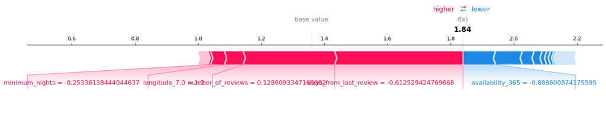

```python
shap.force_plot(
    cat_explainer.expected_value,
    test_cat_shap_values[1, :],
    X_test_enc.iloc[1, :],
    matplotlib = True
)
```

```python
# actual target
y_test.iloc[1]
```

```
1.22
```

## 13. Summary of results

rubric={reasoning}

Imagine that you want to present the summary of these results to your boss and co-workers.

**Your tasks:**

1. Create a table summarizing important results.
2. Write concluding remarks.
3. Discuss other ideas that you did not try but could potentially improve the performance/interpretability .
4. Report your final test score along with the metric you used at the top of this notebook.

*Points:* 8

[output not shown]

```python
pd.DataFrame(cross_val_results)
```

|  | Dummy | Ridge | Random Forests | SVR | LGBMR | CatBoost | CatBoost RFE |
| --- | --- | --- | --- | --- | --- | --- | --- |
| fit_time | 0.014 (+/- 0.002) | 0.029 (+/- 0.011) | 1.035 (+/- 0.311) | 2.254 (+/- 0.417) | 0.253 (+/- 0.003) | 1.595 (+/- 0.062) | 17.229 (+/- 0.431) |
| score_time | 0.004 (+/- 0.000) | 0.004 (+/- 0.000) | 0.020 (+/- 0.001) | 0.829 (+/- 0.111) | 0.006 (+/- 0.000) | 0.059 (+/- 0.001) | 0.012 (+/- 0.009) |
| test_score | -0.001 (+/- 0.001) | 0.395 (+/- 0.038) | 0.607 (+/- 0.035) | 0.472 (+/- 0.029) | 0.614 (+/- 0.044) | 0.628 (+/- 0.037) | 0.595 (+/- 0.034) |
| train_score | 0.000 (+/- 0.000) | 0.439 (+/- 0.010) | 0.945 (+/- 0.002) | 0.535 (+/- 0.008) | 0.811 (+/- 0.009) | 0.815 (+/- 0.003) | 0.765 (+/- 0.008) |

## 14. Creating a data analysis pipeline (Challenging)

rubric={reasoning}

**Your tasks:**

- In 522 you learned how build a reproducible data analysis pipeline. Convert this notebook into scripts and create a reproducible data analysis pipeline with appropriate documentation. Submit your project folder in addition to this notebook on GitHub and briefly comment on your organization in the text box below.

*Points:* 2

The scripts can be found in the same repository of this notebook.

## 15. Your takeaway from the course (Challenging)

rubric={reasoning}

**Your tasks:**

What is your biggest takeaway from this course?

*Points:* 0.25

As a continuation of the DSCI 571 course, we learned how to carry out a supervised machine learning project from EDA, preprocessing, feature engineering and transformation, model building, model selection, feature selection, and presentation and interpretation of results for both classification and regression data sets. I personally am amazed by the number of different models out there and especially the ensemble model that can take the good parts of different models into one.

**Restart, run all and export a PDF before submitting**

Before submitting, don't forget to run all cells in your notebook to make sure there are no errors and so that the TAs can see your plots on Gradescope. You can do this by clicking the ▶▶ button or going to `Kernel -> Restart Kernel and Run All Cells...` in the menu. This is not only important for MDS, but a good habit you should get into before ever committing a notebook to GitHub, so that your collaborators can run it from top to bottom without issues.

After running all the cells, export a PDF of the notebook (preferably the WebPDF export) and upload this PDF together with the ipynb file to Gradescope (you can select two files when uploading to Gradescope)

## Help us improve the labs

The MDS program is continually looking to improve our courses, including lab questions and content. The following optional questions will not affect your grade in any way nor will they be used for anything other than program improvement:

1. Approximately how many hours did you spend working or thinking about this assignment (including lab time)?

# Ans:

2. Do you have any feedback on the lab you be willing to share? For example, any part or question that you particularly liked or disliked?

# Ans: